# Biostat M280 Homework 3

Due Mar 1 @ 11:59PM

Yu Xia

Use tidyverse and bash to explore following two data sets.

## Q1 LA City Employee Payroll

The `/home/m280data/la_payroll/City_Employee_Payroll.csv` file on teaching server contains payroll information of LA City employees in years 2013-2018. It was downloaded from [LA City Controller’s Office](https://controllerdata.lacity.org/Payroll/City-Employee-Payroll/pazn-qyym). Make a Shiny app to facilitate visualization of this data.

1. For efficiency of the Shiny app, you should first pre-process, pare down, tidy, and save the data, e.g., as a compressed RDS file, to be used in the app.

   ```bash
   cat /home/xiayu960112/biostat-m280-2019-winter/hw3/datapreprocessing.R
   ```

   ```
   ## library(readr)
   ## library(tidyverse)
   ## library(reshape2)
   ## library(plotly)
   ## library(ggpubr)
   ## library(gridExtra)
   ##
   ## original <- read_csv("/home/m280data/la_payroll/City_Employee_Payroll.csv")
   ##
   ##
   ## # Q2
   ## yrs <- unique(original$Year) # all years
   ## pay <- c()
   ## for(yr in yrs) { # subset and sum
   ##   pay_yr <- filter(original ,Year == yr) %>%
   ##     select(`Base Pay`, `Overtime Pay`, `Other Pay (Payroll Explorer)`)
   ##   pay_yr <- sapply(pay_yr, function(x) sum(x, na.rm = T))
   ##   new_row <- c(yr, unlist(pay_yr))
   ##   pay <- rbind(pay, new_row)
   ## }
   ## df_year <- data.frame(pay)
   ## colnames(df_year) <- c("Year", "Base Pay", "Overtime Pay", "Other Pay")
   ## saveRDS(df_year, "/home/xiayu960112/biostat-m280-2019-winter/hw3/LA-City-Payroll/TotalPayroll.RDS")
   ##
   ## # Q3
   ## df_employee <- within(original,  Person <- paste(`Department Title`, `Job Class Title`, sep=": ")) # new column for identification
   ## df_employee <- df_employee[order(-df_employee$`Total Payments`),] #sort
   ## df_employee <- df_employee %>%
   ##   select(`Year`, `Total Payments`, `Base Pay`, `Overtime Pay`, `Other Pay (Payroll Explorer)`, `Person`)
   ## colnames(df_employee) <- c("Year", "Total", "Base Pay", "Overtime Pay", "Other Pay", "Person")
   ## saveRDS(df_employee, "/home/xiayu960112/biostat-m280-2019-winter/hw3/LA-City-Payroll/EmployeePayroll.RDS")
   ##
   ## # Q4 and Q5
   ## departments <- unique(original$`Department Title`)
   ## df_department <- c()
   ## for(department in departments) {
   ##   for(yr in yrs) {
   ##     sum <- original %>%
   ##       filter(`Department Title` == department & Year == yr) %>%
   ##       select(`Average Benefit Cost`,`Total Payments`, `Base Pay`, `Overtime Pay`, `Other Pay (Payroll Explorer)`) %>%
   ##       sapply(function(x) sum(x, na.rm = T))
   ##     r <- c(department, yr, unlist(sum))
   ##     df_department <- rbind(df_department, r)
   ##   }
   ## }
   ## df_department <- data.frame(df_department, stringsAsFactors=FALSE)
   ## df_department[,3:7] <- sapply(df_department[,3:7], function(x) as.numeric(as.character(unlist(x))))
   ## df_department <- df_department[order(-df_department$Total.Payments),]
   ## colnames(df_department) <- c("Department", "Year", "Cost","Total", "Base Pay", "Overtime Pay", "Other Pay")
   ## saveRDS(df_department, "/home/xiayu960112/biostat-m280-2019-winter/hw3/LA-City-Payroll/DepartmentPayroll.RDS")
   ## df_department_cost <- df_department[order(-df_department$Cost),]
   ## saveRDS(df_department_cost, "/home/xiayu960112/biostat-m280-2019-winter/hw3/LA-City-Payroll/DepartmentPayrollCost.RDS")
   ##
   ## # Q6
   ## df_full <- original %>%
   ##   select(Year, `Employment Type`)
   ## colnames(df_full) <- c("Year", "Employment Type")
   ## saveRDS(df_full, "/home/xiayu960112/biostat-m280-2019-winter/hw3/LA-City-Payroll/EmploymentType.RDS")
   ```

2. **Total payroll by LA City**. Visualize the total LA City payroll of each year, with breakdown into base pay, overtime pay, and other pay.

**See datapreprocessing.R**

3. **Who earned most?** Visualize the payroll information (total payment with breakdown into base pay, overtime pay, and other pay, Department, Job Title) of the top $n$ highest paid LA City employees in a specific year. User specifies $n$ (default 10) and year (default 2017).

**See datapreprocessing.R**

4. **Which departments earn most?** Visualize the mean or median payroll, with breakdown into base pay, overtime pay, and other pay, of top $n$ earning departments. User specifies $n$ (default 5), year (default 2017), and method (mean or median, default median).

**See datapreprocessing.R**

5. **Which departments cost most?** Visualize the total payroll, with breakdown into base pay, overtime pay, and other pay, of top $n$ expensive departments. User specifies $n$ (default 5) and year (default 2017).

**See datapreprocessing.R**

6. Visualize any other information you are interested in.

**Answer: I have chosen to visualize the distribution of the employment type of employees in each year with pie charts displaying percents of employees who worked full-time, part-time, or event employees.**

7. Publish your Shiny app to https://www.shinyapps.io and share the link.

https://yuxiarain.shinyapps.io/LA-City-Payroll/

## Q2 LA City Parking War

The SQLite database `/home/m280data/la_parking/LA_Parking_Citations.sqlite` on teaching server contains information about parking tickets in LA City. It was downloaded from [LA Open Data Portal](https://data.lacity.org/A-Well-Run-City/Parking-Citations/wjz9-h9np). Connect to the database and answer following questions using plots and summary statistics. In this exercise, you are **not** allowed to load whole data into memory. Use the *transform in database, plot in R* strategy.

1. How many tickets are in this data set? Which time period do these tickets span? Which years have most data?

```r
library("DBI")
library("RSQLite")
library("dplyr")
con = dbConnect(RSQLite::SQLite(), "/home/m280data/la_parking/LA_Parking_Citations.sqlite")
latix <- dplyr::tbl(con,"latix")
df<- latix %>%
  select(Ticket_number, Issue_Year, Issue_Month, Issue_Day, Issue_Hour,
         Issue_Wday, Color, Violation_Description, Fine_amount, Make)
df %>% summarize(n = n())
```

```
## # Source:   lazy query [?? x 1]
## # Database: sqlite 3.22.0
## #   [/home/m280data/la_parking/LA_Parking_Citations.sqlite]
##         n
##     <int>
## 1 7656418
```

```r
df %>% filter(is.na(Issue_Year) == F) %>%
         arrange(Issue_Year, Issue_Month, Issue_Day, Issue_Hour) %>%
         collect() %>%
         slice(c(1,n()))
```

```
## # A tibble: 2 x 10
##   Ticket_number Issue_Year Issue_Month Issue_Day Issue_Hour Issue_Wday
##           <dbl>      <int>       <int>     <int>      <int>      <dbl>
## 1    4259743821       2015           7         2          1          5
## 2    4347488563       2019           1        25         23          6
## # ... with 4 more variables: Color <chr>, Violation_Description <chr>,
## #   Fine_amount <dbl>, Make <chr>
```

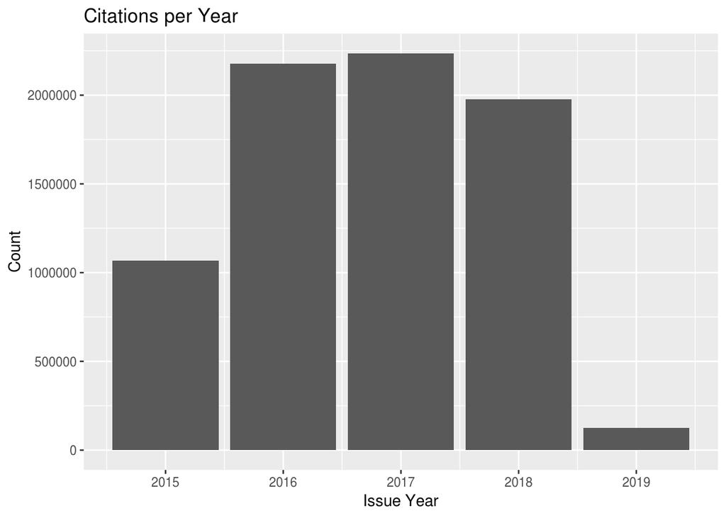

```r
df %>% group_by(Issue_Year) %>%
         filter(is.na(Issue_Year) == F) %>%
         summarise(n = n()) %>%
         collect() %>%
         ggplot() +
            geom_col(aes(x = Issue_Year, y = n)) +
            labs(title = "Citations per Year",
                 x = "Issue Year", y = "Count")
```

**Answer: There are 7656418 tickets in total within the data set. The tickets span from 01:00 on 07/02/2015 to 23:00 on 01/25/2019. 2017 has the most citation tickets.**

2. When (which hour, weekday, month day, and month) are you most likely to get a ticket and when are you least likely to get a ticket?

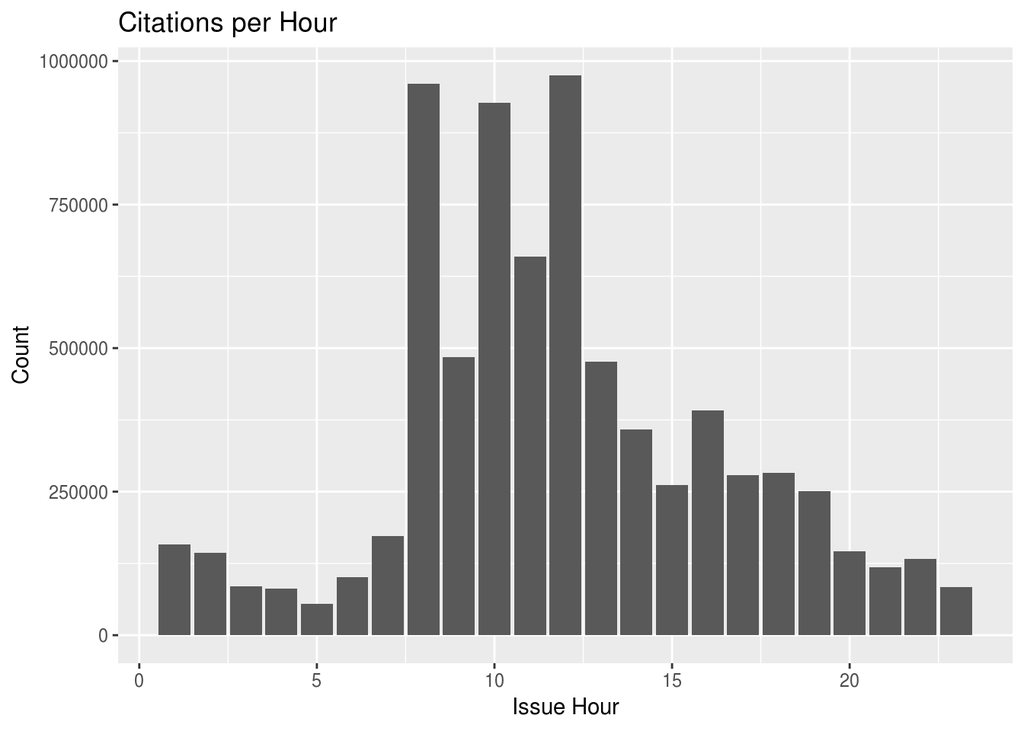

```r
df %>% group_by(Issue_Hour) %>%
  filter(is.na(Issue_Hour) == F) %>%
  summarise(n = n()) %>%
  collect() %>%
  ggplot() +
  geom_col(aes(x = Issue_Hour, y = n)) +
  labs(title = "Citations per Hour",
       x = "Issue Hour", y = "Count")
```

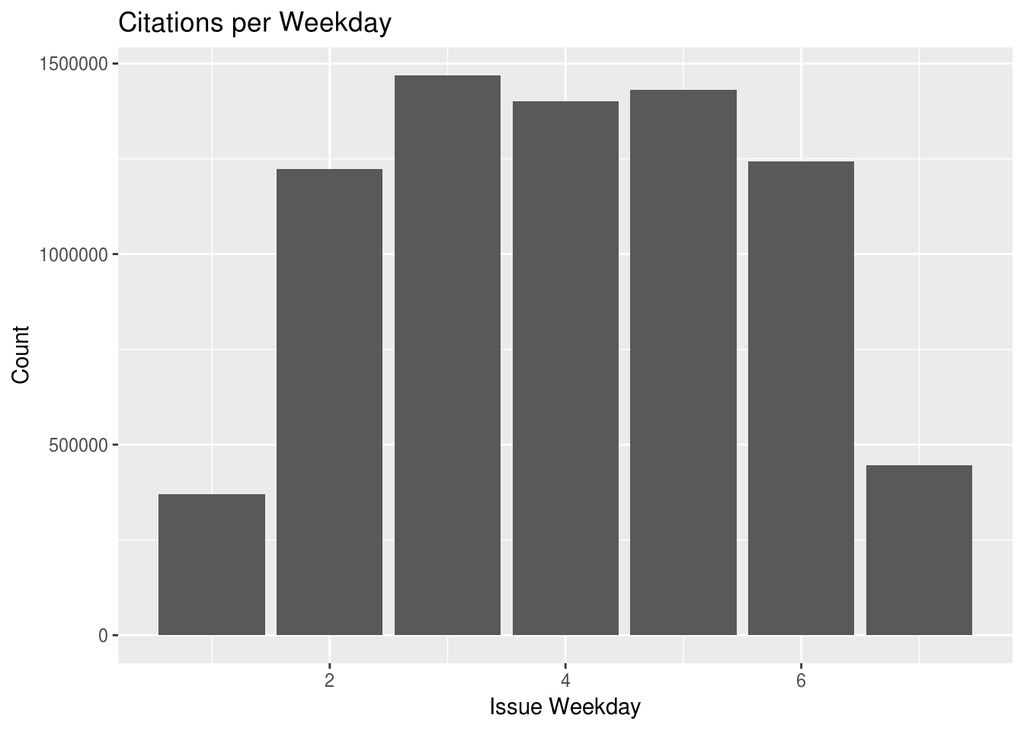

```r
df %>% group_by(Issue_Wday) %>%
  filter(is.na(Issue_Wday) == F) %>%
  summarise(n = n()) %>%
  collect() %>%
  ggplot() +
  geom_col(aes(x = Issue_Wday, y = n)) +
  labs(title = "Citations per Weekday",
       x = "Issue Weekday", y = "Count")
```

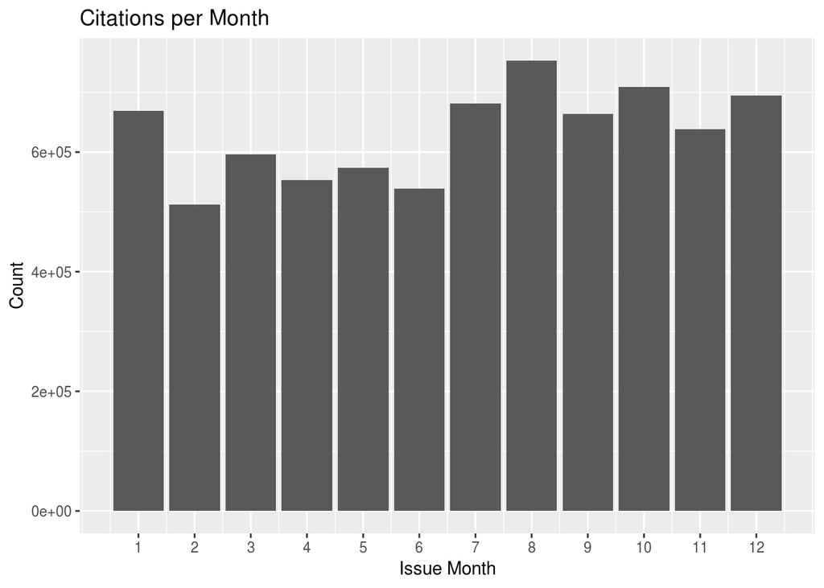

```r
df %>% group_by(Issue_Month) %>%
  filter(is.na(Issue_Month) == F) %>%
  summarise(n = n()) %>%
  collect() %>%
  ggplot() +
  geom_col(aes(x = Issue_Month, y = n)) +
  labs(title = "Citations per Month",
       x = "Issue Month", y = "Count") +
       scale_x_continuous(breaks = c(1:12), labels = c(1:12))
```

```r
df %>% group_by(Issue_Day) %>%
  filter(is.na(Issue_Day) == F) %>%
  summarise(n = n()) %>%
  arrange(n) %>%
  collect() %>%
  slice(c(1,n()))
```

```
## # A tibble: 2 x 2
##   Issue_Day      n
##       <int>  <int>
## 1        31 157356
## 2        13 267419
```

3. Which car makes received most citations?

```r
df %>% group_by(Make) %>%
  filter(is.na(Make) == F) %>%
  summarise(n = n()) %>%
  arrange(desc(n)) %>%
  collect()
```

```
## # A tibble: 2,021 x 2
##    Make        n
##    <chr>   <int>
##  1 TOYT  1270804
##  2 HOND   865088
##  3 FORD   666786
##  4 NISS   552070
##  5 CHEV   519495
##  6 BMW    349172
##  7 MERZ   310812
##  8 VOLK   259663
##  9 HYUN   240399
## 10 DODG   225236
## # ... with 2,011 more rows
```

**Answer: TOYT had the most tickets.**

4. How many different colors of cars were ticketed? Which color attracted most tickets?

```r
df %>% group_by(Color) %>%
  filter(is.na(color) == F) %>%
  summarise(n = n()) %>%
  arrange(desc(n)) %>%
  collect()
```

```
## # A tibble: 103 x 2
##    Color       n
##    <chr>   <int>
##  1 BK    1652621
##  2 WT    1603566
##  3 GY    1497021
##  4 SL     953903
##  5 BL     591858
##  6 RD     378515
##  7 GN     213197
##  8 BN     148980
##  9 GO      97961
## 10 MR      91279
## # ... with 93 more rows
```

**Answer: There are 103 different colors, and BK attracted the most tickets.**

5. What are the most common ticket types?

```r
df %>% group_by(Violation_Description) %>%
  filter(is.na(Violation_Description) == F) %>%
  summarise(n = n()) %>%
  arrange(desc(n)) %>%
  collect()
```

```
## # A tibble: 743 x 2
##    Violation_Description        n
##    <chr>                    <int>
##  1 NO PARK/STREET CLEAN   2234699
##  2 METER EXP.             1302155
##  3 RED ZONE                582135
##  4 PREFERENTIAL PARKING    523775
##  5 DISPLAY OF TABS         472750
##  6 NO PARKING              343489
##  7 DISPLAY OF PLATES       211693
##  8 WHITE ZONE              168596
##  9 PARKED OVER TIME LIMIT  156501
## 10 NO STOP/STANDING        138691
## # ... with 733 more rows
```

**Answer: NO PARK/STREET CLEAN, METER EXP., RED ZONE, and PREFERENTIAL PARKING are the most common types of citation.**

6. How much money was collected on parking tickets in 2016, 2017 and 2018?

```r
df %>%
  filter(is.na(Issue_Year) == F) %>%
  group_by(Issue_Year) %>%
  summarise(sum = sum(Fine_amount), na.rm = TRUE) %>%
  collect()
```

```
## # A tibble: 5 x 3
##   Issue_Year       sum na.rm
##        <int>     <dbl> <int>
## 1       2015  75111152     1
## 2       2016 152145538     1
## 3       2017 157122489     1
## 4       2018 138875787     1
## 5       2019   8743347     1
```

**Answer: 152145538 dollars in 2016; 157122489 dollars in 2017; and 138875787 dollars in 2018.**

7. If you’ve been ticketed in LA County, did you find your ticket in this data set?

**Answer: I did not receive a ticket in LA County.**